# Project 1: Music Genre Classification Analysis

2024-11-3

## Introduction

### Project Background

- **Dataset Source:** Kaggle - Music Genre Classification.
- **Data Files:** Includes train.csv for model training, test.csv for evaluation, and submissions.csv for genre labels.
- **Objective:** Use acoustic features to explore music genres.

## Problem Definition

### Key Questions

1. Can we identify clusters of genres based on energy and tempo?
2. How does the distribution of features like danceability or loudness vary across genres?
3. Can we predict the genre of a song based on its acoustic features using classification algorithms?

## Dataset Overview

### Overview of Features

- Key features: **Energy, Tempo, Danceability, Acousticness, Loudness**
- Target variable: **Genre**

### Training and Testing Sets

- **Train.csv:** Used to build and train the model.
- **Test.csv:** Used for evaluation to assess model generalization.
- **Submissions.csv:** Provides the genre labels for the test set.

## Setup and Loading the Data

### Data Import and Setup

- Loading the training and testing datasets.
- Extracting genre labels from the submissions data.
- Sampling 50% of the data for quicker execution.

## Data Wrangling and Cleaning

### Handling Missing Values and Normalization

- Filling missing values in numeric columns with the mean.
- Normalizing features based on the training dataset.

## Exploratory Data Analysis

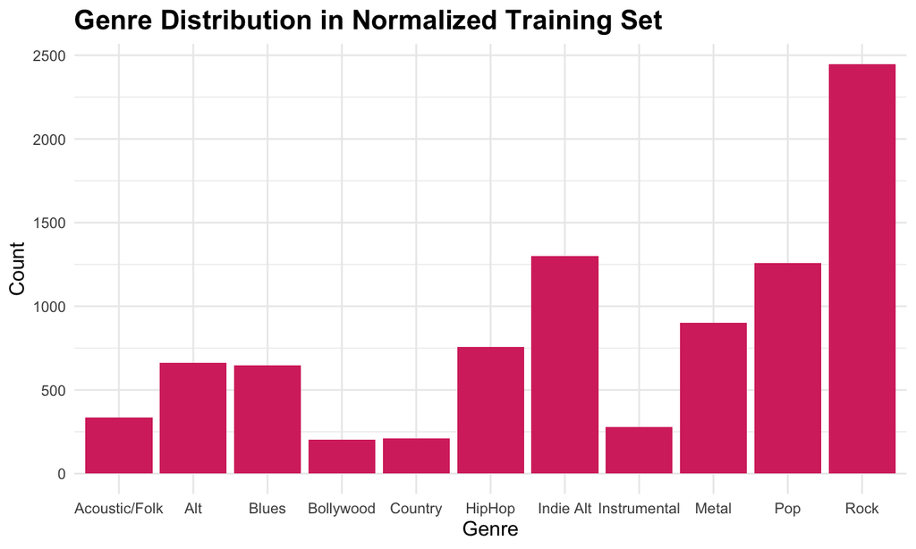

## Clustering Analysis - Methodology

### k-Means Clustering on Training Set

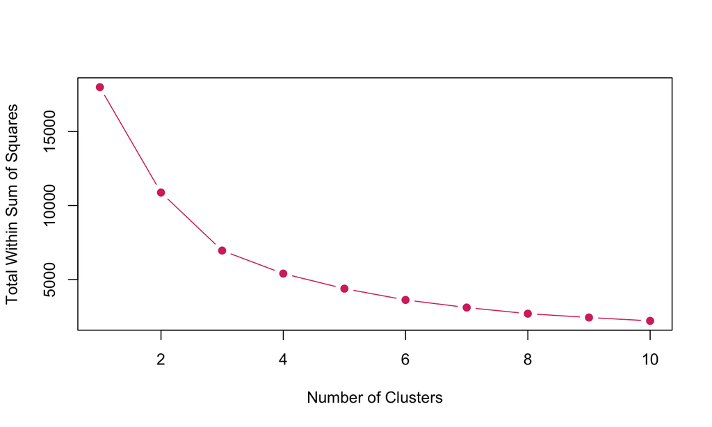

## Clustering Analysis - Results on Training Data

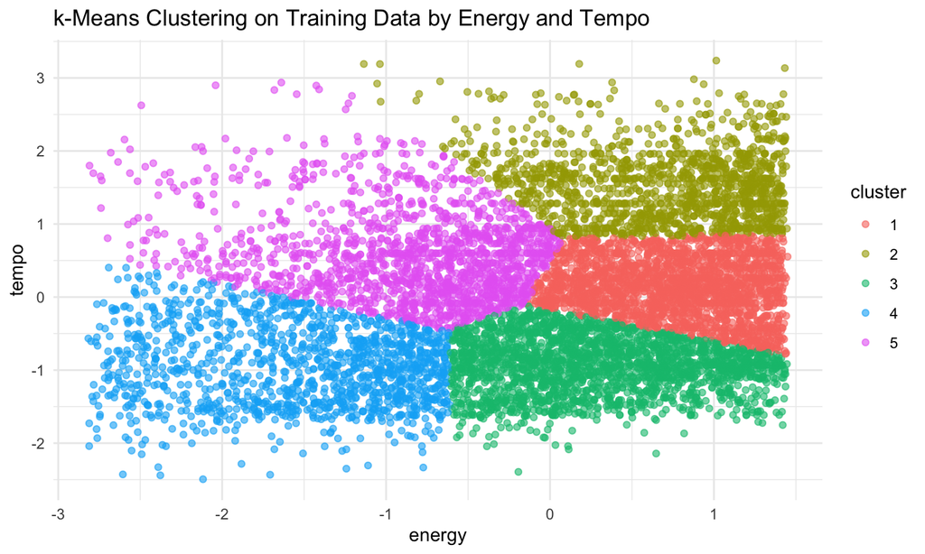

## Distribution of Features Across Genres

- Investigating how features like danceability and loudness vary across genres provides insights into genre characteristics.

## Danceability

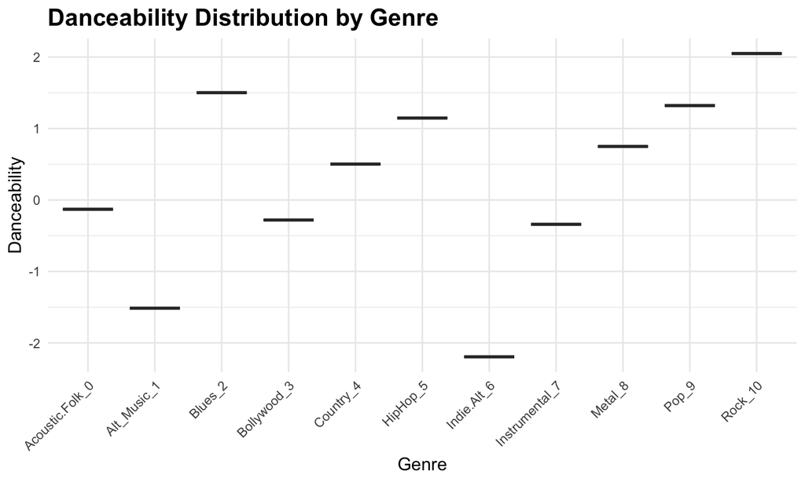

## Loudness

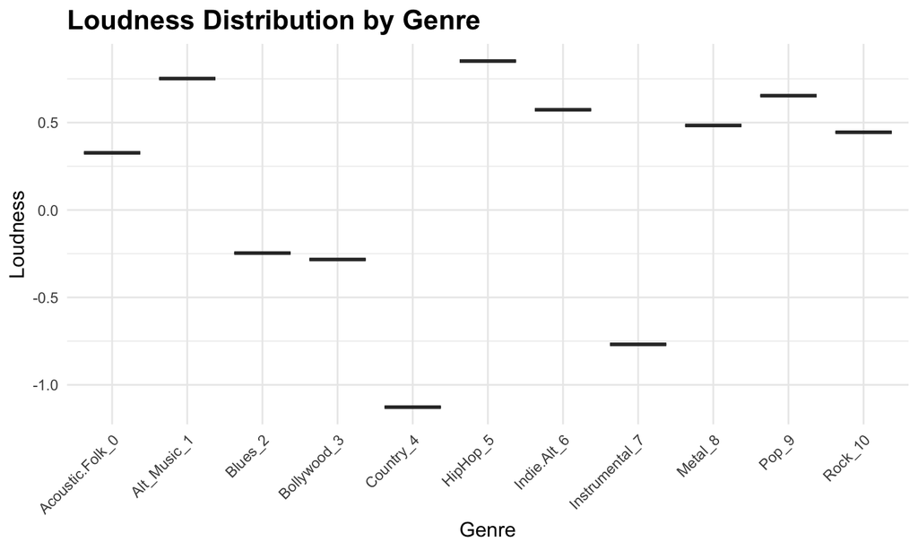